# Ngiam and Lee (2026) - perceptualReproduction

William XQ Ngiam

2025-12-11

## Overview

This file is associated with the preprint titled [“Similarity judgments and visual working memory do not share the same cognitive representation”](https://osf.io/preprints/psyarxiv/fm9vz_v1) by William XQ Ngiam (Adelaide University) and Michael D Lee (University of California Irvine. This research project models the underlying psychological space in perceptual tasks, working memory tasks, and similarity judgment tasks.

The following model recovers the underlying psychological space for the orientation **perceptual reproduction** task in [Tomic and Bays (2024)](https://psycnet.apa.org/doi/10.1037/xlm0001172). In this task, a line at an angle (0 to 180 degrees) is shown to the subject and remains on the screen. The subject reproduces the orientation as closely as possible.

The following code builds a Bayesian Thurstonian model using JAGS. The underlying Thurstonian model is an attempt to recover the representation (much like multidimensional scaling) of the orientations. Then, this model could be used to predict performance on other tasks; such as a working memory task with these orientations.

### Requirements

The following files should be saved in your working directory:

- The data file (“oriPercData_clean.csv”) - [downloadable here](https://github.com/WilliamNgiam/orientationModeling/blob/main/data/oriPercData_clean.csv).
- The model text file (“perceptualReproduction_jags.txt”) - [downloadable here](https://github.com/WilliamNgiam/orientationModeling/blob/main/perceptualReproduction/perceptualReproduction_jags.txt).

You will also need to have installed JAGS on your device. The installer can be accessed here: [https://sourceforge.net/projects/mcmc-jags/files/]. The following code was built using JAGS 4.3.2.

### Setup

```r
# Load required packages
library(R2jags) # v0.8-9
library(tidyverse) # v2.0.0
library(coda) # v0.19-4.1
library(ggmcmc) # v1.5.1.2

# Provide R session output
```

```r
# Set RNG seed for reproducibility
set.seed(123)
```

### Load data

```r
# Load in Tomic and Bays (2024) dataset
percData <- read_csv(paste0(getwd(),"/oriPercData_clean.csv"))

# Create intervals to match the Tomic and Bays (2024) perceptual task.
binIntervals = seq(0,pi,length.out = 73)

# Assign indices to the closest interval for the target (stimulus) values and response values
percData <- percData %>%
  mutate(response = round(response,digits = 5),
         target = round(target,digits = 5)) %>%
  # Make all values positive
  mutate(response = response/2,
         target = target/2) %>%
  mutate(response = case_when(response < 0 ~ response + pi,
                              .default = response),
         target = case_when(target < 0 ~ target + pi,
                            .default = target)) %>%
  # Adjust response values to account for circular angle
  mutate(response = case_when(abs(response-target) > abs(response-target-pi) ~ response-pi,
                              .default = response)) %>%
  mutate(response = case_when(abs(target-response) > abs(target-response-pi) ~ response+pi,
                              .default = response)) %>%
  rowwise() %>%
  # Match target values to the intervals on the semi-circle
  mutate(targetIndex = which.min(abs(target-binIntervals))) %>%
  # The target values closest to pi are re-indexed to the first bin (0 degrees)
  mutate(targetIndex = case_when(targetIndex == 73 ~ 1,
                                 .default = targetIndex))

# Set up the true values to be recovered
muTruth = binIntervals[-73] # Remove the last index because that is the point at which the circle wraps around
sigmaTruth = 0.01

# Assign data to vectors
s <- as.integer(percData$targetIndex)
y <- as.numeric(percData$response)
nTrials <- as.integer(length(percData$response))
nStimuli <- as.integer(length(muTruth))
```

### Read in data for JAGS

```r
data.jags <- list("s","y","nTrials","nStimuli")
bayes.mod.params <- c("mu","sigma")
bayes.mod.inits <- function() {
  list("sigma" = runif(1)*pi)
}
```

### Run model fit

```r
bayes.mod.fit <- jags(data = data.jags,
                      inits = bayes.mod.inits,
                      parameters.to.save = bayes.mod.params,
                      n.chains = 8,
                      n.iter = 8000,
                      n.burnin = 2000,
                      model.file = paste0(getwd(),"/perceptualReproduction_jags.txt"))
```

```
## module glm loaded
```

```
## Compiling data graph
##    Initializing
##    Reading data back into data table
##
```

### Evaluate model

```r
print(bayes.mod.fit)
```

```
## Inference for Bugs model at "/Users/will.ngiam/Documents/1 RESEARCH/10 Projects/10.05 Generated MDS/simiJAGS/perceptualReproduction_jags.txt", fit using jags,
##  8 chains, each with 8000 iterations (first 2000 discarded), n.thin = 6
##  n.sims = 8000 iterations saved. Running time = 74.121 secs
##           mu.vect sd.vect     2.5%      25%      50%      75%    97.5%  Rhat
## mu[1]       0.000   0.000    0.000    0.000    0.000    0.000    0.000 1.000
## mu[2]       0.058   0.030    0.006    0.035    0.056    0.078    0.119 1.001
## mu[3]       0.102   0.033    0.038    0.080    0.102    0.124    0.168 1.001
## mu[4]       0.156   0.032    0.093    0.134    0.156    0.178    0.219 1.001
## mu[5]       0.217   0.036    0.147    0.193    0.217    0.241    0.287 1.001
## mu[6]       0.264   0.036    0.194    0.239    0.264    0.289    0.333 1.001
## mu[7]       0.310   0.032    0.247    0.289    0.310    0.332    0.373 1.001
## mu[8]       0.363   0.035    0.295    0.338    0.363    0.386    0.431 1.002
## mu[9]       0.378   0.032    0.316    0.357    0.379    0.401    0.441 1.001
## mu[10]      0.436   0.038    0.362    0.410    0.436    0.462    0.511 1.001
## mu[11]      0.477   0.032    0.413    0.455    0.476    0.499    0.540 1.001
## mu[12]      0.504   0.038    0.430    0.479    0.504    0.529    0.579 1.001
## mu[13]      0.577   0.039    0.498    0.550    0.577    0.603    0.653 1.001
## mu[14]      0.590   0.035    0.521    0.566    0.590    0.613    0.659 1.001
## mu[15]      0.641   0.035    0.573    0.617    0.640    0.665    0.710 1.001
## mu[16]      0.690   0.033    0.625    0.668    0.690    0.713    0.756 1.001
## mu[17]      0.729   0.030    0.669    0.708    0.729    0.749    0.789 1.001
## mu[18]      0.756   0.036    0.686    0.732    0.757    0.780    0.828 1.001
## mu[19]      0.804   0.035    0.737    0.780    0.804    0.827    0.873 1.002
## mu[20]      0.849   0.035    0.781    0.825    0.848    0.872    0.918 1.001
## mu[21]      0.922   0.035    0.854    0.898    0.922    0.945    0.990 1.001
## mu[22]      0.931   0.033    0.865    0.908    0.931    0.953    0.995 1.001
## mu[23]      0.971   0.032    0.909    0.951    0.972    0.993    1.032 1.001
## mu[24]      0.998   0.033    0.934    0.976    0.999    1.020    1.063 1.001
## mu[25]      1.065   0.031    1.002    1.044    1.065    1.085    1.125 1.002
## mu[26]      1.081   0.031    1.020    1.061    1.082    1.102    1.143 1.002
## mu[27]      1.110   0.033    1.047    1.088    1.110    1.132    1.175 1.001
## mu[28]      1.160   0.034    1.091    1.137    1.160    1.183    1.227 1.001
## mu[29]      1.201   0.036    1.132    1.176    1.201    1.225    1.271 1.001
## mu[30]      1.227   0.032    1.163    1.206    1.227    1.249    1.290 1.001
## mu[31]      1.287   0.034    1.220    1.264    1.287    1.311    1.353 1.001
## mu[32]      1.303   0.034    1.234    1.280    1.303    1.326    1.369 1.001
## mu[33]      1.365   0.031    1.304    1.344    1.365    1.385    1.425 1.001
## mu[34]      1.428   0.037    1.356    1.402    1.427    1.453    1.501 1.001
## mu[35]      1.448   0.031    1.388    1.426    1.447    1.470    1.510 1.001
## mu[36]      1.516   0.032    1.454    1.495    1.516    1.537    1.577 1.001
```

[output cut: 105 more lines]

```
## mu[67]    6000
## mu[68]    8000
## mu[69]    6600
## mu[70]    8000
## mu[71]    3500
## mu[72]    8000
## sigma     8000
## deviance  7800
##
## For each parameter, n.eff is a crude measure of effective sample size,
## and Rhat is the potential scale reduction factor (at convergence, Rhat=1).
##
## DIC info (using the rule: pV = var(deviance)/2)
## pV = 72.8 and DIC = 1479.0
## DIC is an estimate of expected predictive error (lower deviance is better).
```

```r
bayes.mod.fit.mcmc <- as.mcmc(bayes.mod.fit)
summary(bayes.mod.fit.mcmc)
```

```
##
## Iterations = 2006:8000
## Thinning interval = 6
## Number of chains = 8
## Sample size per chain = 1000
##
## 1. Empirical mean and standard deviation for each variable,
##    plus standard error of the mean:
##
##               Mean        SD  Naive SE Time-series SE
## deviance 1.406e+03 12.064538 1.349e-01      1.320e-01
## mu[1]    0.000e+00  0.000000 0.000e+00      0.000e+00
## mu[10]   4.362e-01  0.038252 4.277e-04      4.265e-04
## mu[11]   4.766e-01  0.032234 3.604e-04      3.602e-04
## mu[12]   5.036e-01  0.037795 4.226e-04      4.270e-04
## mu[13]   5.766e-01  0.039324 4.397e-04      4.370e-04
## mu[14]   5.898e-01  0.034895 3.901e-04      3.997e-04
## mu[15]   6.407e-01  0.035134 3.928e-04      3.856e-04
## mu[16]   6.904e-01  0.033312 3.724e-04      3.692e-04
## mu[17]   7.288e-01  0.030349 3.393e-04      3.406e-04
## mu[18]   7.562e-01  0.036195 4.047e-04      3.976e-04
## mu[19]   8.042e-01  0.034708 3.880e-04      4.065e-04
## mu[2]    5.755e-02  0.029787 3.330e-04      3.425e-04
## mu[20]   8.486e-01  0.035204 3.936e-04      3.937e-04
## mu[21]   9.218e-01  0.034821 3.893e-04      3.795e-04
## mu[22]   9.307e-01  0.032930 3.682e-04      3.695e-04
## mu[23]   9.715e-01  0.031608 3.534e-04      3.518e-04
## mu[24]   9.985e-01  0.032831 3.671e-04      3.619e-04
## mu[25]   1.065e+00  0.031081 3.475e-04      3.454e-04
## mu[26]   1.081e+00  0.031300 3.499e-04      3.452e-04
## mu[27]   1.110e+00  0.032721 3.658e-04      3.689e-04
## mu[28]   1.160e+00  0.034334 3.839e-04      3.845e-04
## mu[29]   1.201e+00  0.035968 4.021e-04      3.998e-04
## mu[3]    1.022e-01  0.033113 3.702e-04      3.595e-04
## mu[30]   1.227e+00  0.031879 3.564e-04      3.582e-04
## mu[31]   1.287e+00  0.033830 3.782e-04      3.836e-04
## mu[32]   1.303e+00  0.034151 3.818e-04      3.771e-04
## mu[33]   1.365e+00  0.030867 3.451e-04      3.458e-04
## mu[34]   1.428e+00  0.037142 4.153e-04      4.151e-04
## mu[35]   1.448e+00  0.031207 3.489e-04      3.443e-04
```

[output cut: 107 more lines]

```
## mu[62]   2.559e+00 2.603e+00 2.626e+00 2.651e+00    2.6942
## mu[63]   2.610e+00 2.652e+00 2.675e+00 2.698e+00    2.7401
## mu[64]   2.655e+00 2.698e+00 2.721e+00 2.743e+00    2.7838
## mu[65]   2.711e+00 2.752e+00 2.774e+00 2.796e+00    2.8372
## mu[66]   2.732e+00 2.773e+00 2.794e+00 2.815e+00    2.8551
## mu[67]   2.787e+00 2.832e+00 2.855e+00 2.878e+00    2.9212
## mu[68]   2.831e+00 2.877e+00 2.901e+00 2.924e+00    2.9682
## mu[69]   2.857e+00 2.901e+00 2.924e+00 2.946e+00    2.9897
## mu[7]    2.474e-01 2.888e-01 3.102e-01 3.318e-01    0.3729
## mu[70]   2.933e+00 2.973e+00 2.995e+00 3.016e+00    3.0568
## mu[71]   2.967e+00 3.009e+00 3.032e+00 3.054e+00    3.0963
## mu[72]   3.032e+00 3.076e+00 3.097e+00 3.116e+00    3.1385
## mu[8]    2.946e-01 3.384e-01 3.626e-01 3.863e-01    0.4307
## mu[9]    3.156e-01 3.571e-01 3.789e-01 4.005e-01    0.4405
## sigma    2.732e-01 2.768e-01 2.786e-01 2.804e-01    0.2841
```

### Plots

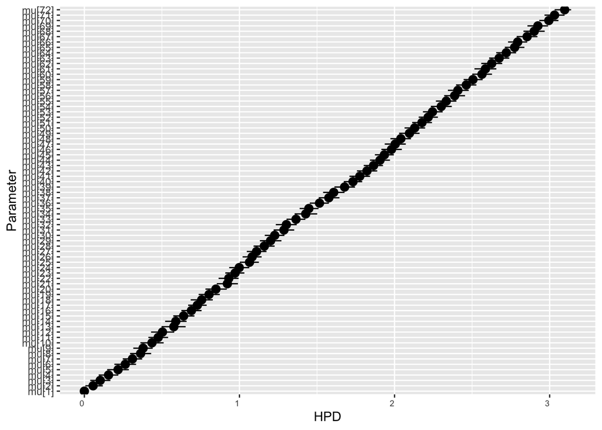

```r
# Convert into ggmcmc object
bayes.mod.fit.gg <- ggs(bayes.mod.fit.mcmc)

ggs_caterpillar(bayes.mod.fit.gg,
                thick_ci = c(0.45,0.55),
                family = "mu",
                sort = FALSE)
```

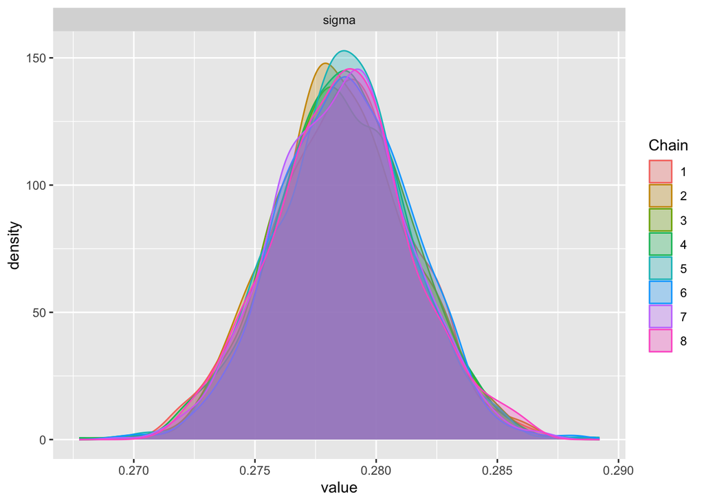

```r
ggs_density(bayes.mod.fit.gg,
            family = "sigma")
```